# Northwind Traders Sales Analysis

- **Author**: [Andy Wang](https://www.linkedin.com/in/andy-wang-3b595a299/), Johns Hopkins University, Class of 2027
- **Github Repository**: https://github.com/sirandy3000/projects/tree/master/northwind

### Scenario

In this project, I assume the role of Data Analyst at Northwind Traders, an international gourmet food distributor. Management is looking to you for insights to make strategic decisions in several aspects of the business. The projects focus on:

- Evaluating employee performance to boost productivity,
- Understanding product sales and category performance to optimize inventory and marketing strategies,
- Analyzing sales growth to identify trends, monitor company progress, and make more accurate forecasts,
- And evaluating customer purchase behavior to target high-value customers with promotional incentives.

To achieve these goals, I use PL/pgSQL to analyze the Northwind PostgreSQL database. I compose complex queries using such techniques as window functions and CTEs, and I create views and stored functions to aid the analysis. I then use the retrieved data to create elegant visualizations using *ggplot2*, providing essential insights to management and contributing significantly to the company’s strategic decisions.

**Note: from here on, text within the scenario is bolded.**

### 1. Database Setup/Connection

I use the *DBI* and *RPostgres* libraries as a backend to execute all SQL statements/queries in this notebook against the Northwind database on my local PostgreSQL server. To copy this database onto any PostgreSQL server, use the *northwind.sql* file found in this repository.

```r
library(DBI)
library(ggplot2)
library(patchwork)
library(RPostgres)
library(scales)
library(tibble)

conn <- DBI::dbConnect(
  RPostgres::Postgres(),
  dbname = "northwind",
  host = "localhost",
  user = "postgres",
  password = password,
  port = 5432
)
```

### 2. Database Exploration

**Familiarize yourself with the Northwind company: explore the tables and their relationships, and create a schema diagram.**

Throughout this notebook, I create several functions and views for convenience in executing complex queries. Here, I drop them to allow the notebook to be easily rerun.

```r
dbExecute(conn, "DROP FUNCTION IF EXISTS show_tables;")
dbExecute(conn, "DROP FUNCTION IF EXISTS describe_table;")
dbExecute(conn, "DROP FUNCTION IF EXISTS full_name;")
dbExecute(conn, "DROP VIEW IF EXISTS order_prices;")
dbExecute(conn, "DROP VIEW IF EXISTS order_months;")
dbExecute(conn, "DROP VIEW IF EXISTS product_percentiles;")
dbExecute(conn, "DROP FUNCTION IF EXISTS products_over_percentile;")
```

I first created a function to list all the tables and views in the current database.

```r
dbExecute(conn, paste(
  "CREATE FUNCTION show_tables() RETURNS TABLE (",
    "name information_schema.sql_identifier,",
    "type information_schema.character_data",
  ") LANGUAGE plpgsql AS $$ BEGIN RETURN QUERY",
  "SELECT table_name, table_type",
  "FROM information_schema.tables",
  "WHERE table_schema = 'public' AND table_type IN ('BASE TABLE', 'VIEW')",
  "ORDER BY 1; END $$;"
))
```

I then created a function to list all the columns of a given table, along with their data types and whether null values are allowed.

```r
dbExecute(conn, paste(
  "CREATE FUNCTION describe_table(table_name_ varchar) RETURNS TABLE (",
    "variable information_schema.sql_identifier,",
    "type information_schema.character_data,",
    "nullable information_schema.yes_or_no",
  ") LANGUAGE plpgsql AS $$ BEGIN RETURN QUERY",
  "SELECT column_name, data_type, is_nullable",
  "FROM information_schema.columns",
  "WHERE table_name = table_name_",
  "ORDER BY 1; END $$;"
))
```

```r
as_tibble(dbGetQuery(conn, "SELECT * FROM show_tables();"))
```

```
## # A tibble: 15 × 2
##    name                   type
##    <chr>                  <chr>
##  1 categories             BASE TABLE
##  2 customer_customer_demo BASE TABLE
##  3 customer_demographics  BASE TABLE
##  4 customers              BASE TABLE
##  5 employee_territories   BASE TABLE
##  6 employees              BASE TABLE
##  7 order_details          BASE TABLE
##  8 orders                 BASE TABLE
##  9 product_sales          VIEW
## 10 products               BASE TABLE
## 11 region                 BASE TABLE
## 12 shippers               BASE TABLE
## 13 suppliers              BASE TABLE
## 14 territories            BASE TABLE
## 15 us_states              BASE TABLE
```

```r
as_tibble(dbGetQuery(conn, "SELECT * FROM describe_table('orders');"))
```

```
## # A tibble: 14 × 3
##    variable         type              nullable
##    <chr>            <chr>             <chr>
##  1 customer_id      character varying YES
##  2 employee_id      smallint          YES
##  3 freight          real              YES
##  4 order_date       date              YES
##  5 order_id         smallint          NO
##  6 required_date    date              YES
##  7 ship_address     character varying YES
##  8 ship_city        character varying YES
##  9 ship_country     character varying YES
## 10 ship_name        character varying YES
## 11 ship_postal_code character varying YES
## 12 ship_region      character varying YES
## 13 ship_via         smallint          YES
## 14 shipped_date     date              YES
```

```r
as_tibble(dbGetQuery(conn, "SELECT * FROM describe_table('products');"))
```

```
## # A tibble: 10 × 3
##    variable          type              nullable
##    <chr>             <chr>             <chr>
##  1 category_id       smallint          YES
##  2 discontinued      integer           NO
##  3 product_id        smallint          NO
##  4 product_name      character varying NO
##  5 quantity_per_unit character varying YES
##  6 reorder_level     smallint          YES
##  7 supplier_id       smallint          YES
##  8 unit_price        real              YES
##  9 units_in_stock    smallint          YES
## 10 units_on_order    smallint          YES
```

After exploring all the tables, I created the following schema diagram, containing the six tables used in the rest of this notebook.

[figure not shown]

### 3. Ranking Employee Sales Performance

**As the lead Data Analyst at Northwind Traders, you’ve been tasked with comprehensively reviewing the company’s sales performance from an employee perspective. The objective is twofold:**

- **First, the management team wants to recognize and reward top-performing employees, fostering a culture of excellence within the organization.**
- **Second, they want to identify employees who might be struggling so that they can offer the necessary training or resources to help them improve.**

**The management team is keen on encouraging healthy competition and rewarding stellar performers. They’ve asked you to rank employees based on their total sales amount, then compare each employee’s sales performance to the average sales performance of all employees to evaluate their contributions.**

I first created a view that stores the total price of each order, appropriately combining unit price, quantity, and possible discounts.

```r
dbExecute(conn, paste(
  "CREATE VIEW order_prices AS",
  "SELECT order_id, product_id, unit_price * quantity * (1 - discount) price",
  "FROM order_details;"
))
```

I then created a function that concatenates first and last names, stored separately, into full names.

```r
dbExecute(conn, paste(
  "CREATE FUNCTION full_name(first_name varchar, last_name varchar)",
  "RETURNS varchar LANGUAGE plpgsql AS $$ BEGIN",
  "RETURN (SELECT first_name || ' ' || last_name); END $$;"
))
```

```r
df_3 <- as_tibble(dbGetQuery(conn, paste(
  "WITH employee_totals AS (",
    "SELECT last_name, first_name, SUM(COALESCE(price, 0)) total",
    "FROM employees LEFT JOIN orders USING (employee_id)",
      "INNER JOIN order_prices USING (order_id)",
    "GROUP BY employee_id, 1, 2",
  ")",
  "SELECT full_name(first_name, last_name), total::int total_sales,",
    "RANK() OVER (ORDER BY total DESC) sales_rank,",
    "(total - (SELECT AVG(total) FROM employee_totals)) /",
      "(SELECT AVG(total) FROM employee_totals) pct_compared_to_avg",
  "FROM employee_totals ORDER BY 3, 1;"
)))

df_3
```

```
## # A tibble: 9 × 4
##   full_name        total_sales sales_rank pct_compared_to_avg
##   <chr>                  <int>    <int64>               <dbl>
## 1 Margaret Peacock      232891          1              0.656
## 2 Janet Leverling       202813          2              0.442
## 3 Nancy Davolio         192108          3              0.366
## 4 Andrew Fuller         166538          4              0.184
## 5 Laura Callahan        126862          5             -0.0980
## 6 Robert King           124568          6             -0.114
## 7 Anne Dodsworth         77308          7             -0.450
## 8 Michael Suyama         73913          8             -0.474
## 9 Steven Buchanan        68792          9             -0.511
```

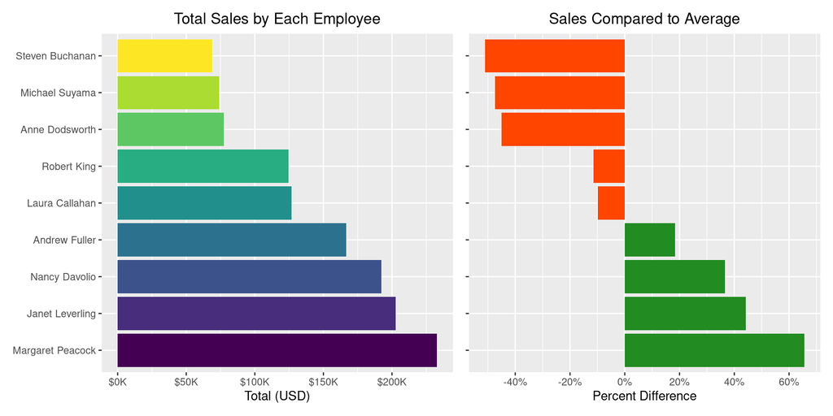

```r
df_3$full_name <- factor(df_3$full_name, levels = df_3$full_name)

fig_3a <-
  ggplot(df_3, aes(total_sales, full_name)) +
  geom_col(aes(fill = full_name)) +
  scale_x_continuous(
    breaks = seq(0, 200000, 50000),
    labels = label_dollar(scale = 0.001, suffix = "K")
  ) +
  scale_fill_viridis_d(guide="none") +
  labs(title = "Total Sales by Each Employee", x = "Total (USD)", y = NULL) +
  theme(plot.title = element_text(hjust = 0.5))

fig_3b <-
  ggplot(df_3, aes(pct_compared_to_avg, full_name)) +
  geom_col(aes(fill = pct_compared_to_avg > 0)) +
  scale_x_continuous(breaks = seq(-0.4, 0.6, 0.2), labels = label_percent()) +
  scale_y_discrete(labels = NULL) +
  scale_fill_manual(values = c("orangered", "forestgreen"), guide="none") +
  labs(title = "Sales Compared to Average", x = "Percent Difference", y = NULL) +
  theme(plot.title = element_text(hjust = 0.5))

fig_3a + fig_3b
```

### 4. Running Total of Monthly Sales

**Having completed the employee performance ranking, you’ve provided the management team with valuable insights into individual employee contributions. They’re now keen on gaining a more macro-level perspective, specifically around the company’s overall sales performance over time. They’re looking to visualize the progress of the sales and identify trends that might shape the company’s future strategies.**

**Your first task in this new analysis is to visualize the company’s sales progress over time on a monthly basis. This will involve aggregating the sales data at a monthly level and calculating a running total of sales by month. This visual will provide the management team with a clear depiction of sales trends and help identify periods of high or low sales activity.**

**After this, the management team would like to analyze the month-over-month sales growth rate. Understanding the rate at which sales are increasing or decreasing from month to month will help the management team identify significant trends. For this task, you’ll need to calculate the percentage change in sales from one month to the next.**

```r
dbExecute(conn, paste(
  "CREATE VIEW order_months (order_id, month_) AS",
  "SELECT order_id, DATE_TRUNC('month', order_date) FROM orders;"
))
```

```r
df_4 <- as_tibble(dbGetQuery(conn, paste(
  "WITH monthly_totals AS (",
    "SELECT month_, SUM(price) total",
    "FROM order_months INNER JOIN order_prices USING (order_id)",
    "GROUP BY 1",
  ")",
  "SELECT month_, total::int,",
    "(SUM(total) OVER (ORDER BY month_))::int running_total,",
    "COALESCE((total - LAG(total) OVER (ORDER BY month_)) /",
      "LAG(total) OVER (ORDER BY month_), 0) percent_change",
  "FROM monthly_totals ORDER BY 1;"
)))

df_4
```

```
## # A tibble: 23 × 4
##    month_              total running_total percent_change
##    <dttm>              <int>         <int>          <dbl>
##  1 1996-07-01 00:00:00 27862         27862        0
##  2 1996-08-01 00:00:00 25485         53347       -0.0853
##  3 1996-09-01 00:00:00 26381         79729        0.0352
##  4 1996-10-01 00:00:00 37516        117244        0.422
##  5 1996-11-01 00:00:00 45600        162844        0.215
##  6 1996-12-01 00:00:00 45240        208084       -0.00790
##  7 1997-01-01 00:00:00 61258        269342        0.354
##  8 1997-02-01 00:00:00 38484        307826       -0.372
##  9 1997-03-01 00:00:00 38547        346373        0.00165
## 10 1997-04-01 00:00:00 53033        399406        0.376
## # ℹ 13 more rows
```

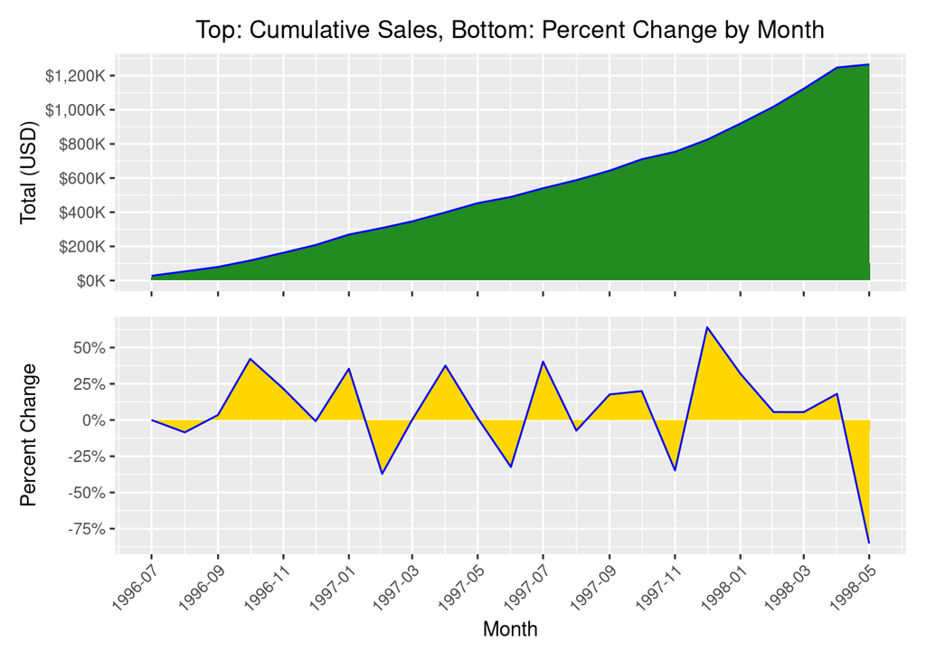

```r
fig_4a <-
  ggplot(df_4, aes(month_, running_total)) +
  geom_area(color = "blue", fill = "forestgreen") +
  scale_x_datetime(breaks = "2 months", labels = NULL) +
  scale_y_continuous(
    breaks = seq(0, 1200000, 200000),
    labels = label_dollar(scale = 0.001, suffix = "K")
  ) +
  labs(
    title = "Top: Cumulative Sales, Bottom: Percent Change by Month",
    x = NULL, y = "Total (USD)"
  ) +
  theme(plot.title = element_text(hjust = 0.5))

fig_4b <-
  ggplot(df_4, aes(month_, percent_change)) +
  geom_area(color = "blue", fill = "gold") +
  scale_x_datetime(breaks = "2 months", labels = label_date("%Y-%m")) +
  scale_y_continuous(breaks = seq(-0.75, 0.75, 0.25), labels = label_percent()) +
  labs(x = "Month", y = "Percent Change") +
  theme(axis.text.x = element_text(angle = 45, hjust = 1))

fig_4a / fig_4b
```

### 5. Identifying High-Value Customers

**Upon completing the sales growth and trend analysis, you’ve provided the management team valuable insights into the company’s sales performance over time. Now, they’re interested in a different, equally important, aspect of the business: the customers.**

**They want to identify high-value customers to whom they can offer targeted promotions and special offers, which could drive increased sales, improve customer retention, and attract new customers.**

**To do this, they’ve asked you to identify customers with above-average order values. These customers might be businesses buying in bulk or individuals purchasing high-end products.**

```r
df_5 <- as_tibble(dbGetQuery(conn, paste(
  "WITH customer_totals AS (",
    "SELECT customer_id, SUM(price) total",
    "FROM orders INNER JOIN order_prices USING (order_id)",
    "GROUP BY 1",
  ")",
  "SELECT contact_name, country, total::int",
  "FROM customers INNER JOIN customer_totals USING (customer_id)",
  "WHERE total > (SELECT AVG(total) FROM customer_totals)",
  "ORDER BY 3 DESC, 1;"
)))

print(df_5, n = Inf)
```

```
## # A tibble: 30 × 3
##    contact_name       country      total
##    <chr>              <chr>        <int>
##  1 Horst Kloss        Germany     110277
##  2 Roland Mendel      Austria     104875
##  3 Jose Pavarotti     USA         104362
##  4 Paula Wilson       USA          51098
##  5 Patricia McKenna   Ireland      49980
##  6 Mario Pontes       Brazil       32841
##  7 Philip Cramer      Germany      30908
##  8 Maria Larsson      Sweden       29568
##  9 Jean Fresnière     Canada       28872
## 10 Karl Jablonski     USA          27364
## 11 Peter Franken      Germany      26657
## 12 Lúcia Carvalho     Brazil       25717
```

[output cut: 18 more lines]

### 6. Percentage of Sales for Each Category

**Having successfully identified customers with above-average order values, you’ve been asked to switch gears and focus on another critical aspect of the company’s operations: product and category performance.**

**You’ve been asked to provide the management team with an understanding of sales composition across different product categories. By knowing the percentage of total sales for each product category, they can gain insights into which categories drive most of the company’s sales.**

**This understanding will help guide decisions about inventory (e.g., which categories should be stocked more heavily) and marketing strategies (e.g., which categories should be promoted more aggressively).**

```r
df_6 <- as_tibble(dbGetQuery(conn, paste(
  "WITH category_totals AS (",
    "SELECT category_id, SUM(COALESCE(price, 0)) total",
    "FROM categories LEFT JOIN products USING (category_id)",
      "LEFT JOIN order_prices USING (product_id)",
    "GROUP BY 1",
  ")",
  "SELECT category_name, total sales, total / (SELECT SUM(total) FROM category_totals) pct_of_total",
  "FROM categories INNER JOIN category_totals USING (category_id)",
  "ORDER BY 2 DESC, 1;"
)))

df_6
```

```
## # A tibble: 8 × 3
##   category_name    sales pct_of_total
##   <chr>            <dbl>        <dbl>
## 1 Beverages      267868.       0.212
## 2 Dairy Products 234507.       0.185
## 3 Confections    167357.       0.132
## 4 Meat/Poultry   163022.       0.129
## 5 Seafood        131262.       0.104
## 6 Condiments     106047.       0.0838
## 7 Produce         99985.       0.0790
## 8 Grains/Cereals  95745.       0.0756
```

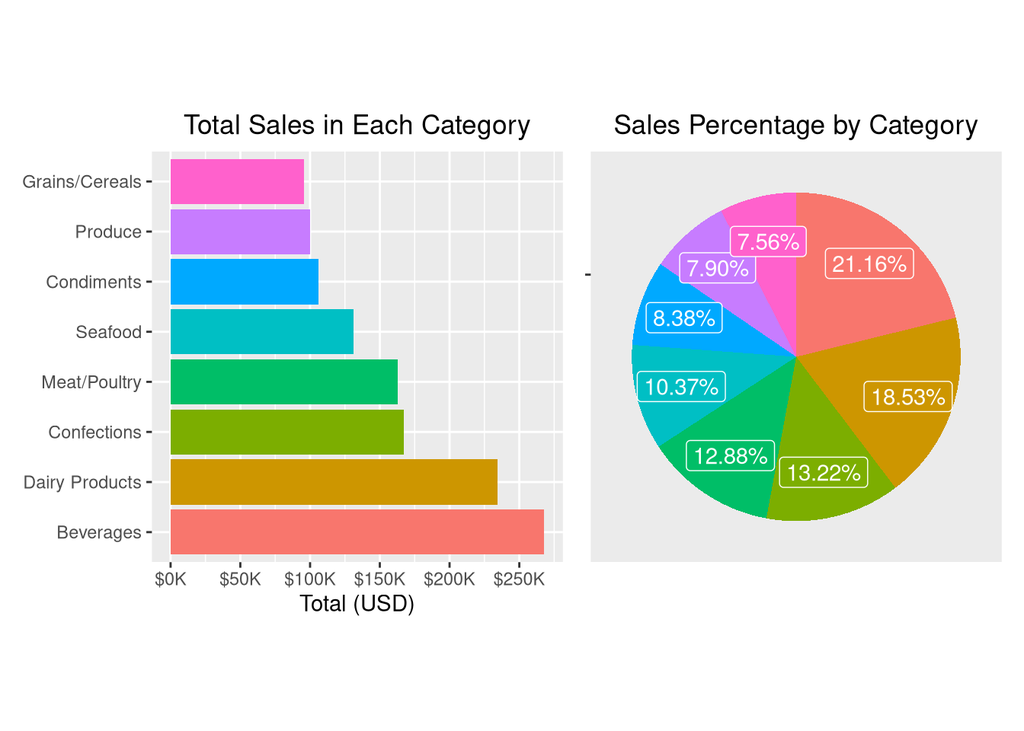

```r
df_6$category_name <- factor(df_6$category_name, levels = df_6$category_name)

fig_6a <-
  ggplot(df_6, aes(sales, category_name)) +
  geom_col(aes(fill = category_name)) +
  scale_x_continuous(
    breaks = seq(0, 300000, 50000),
    labels = label_dollar(scale = 0.001, suffix = "K")
  ) +
  scale_fill_discrete(guide = "none") +
  labs(title = "Total Sales in Each Category", x = "Total (USD)", y = NULL) +
  theme(plot.title = element_text(hjust = 0.5))

fig_6b <-
  ggplot(df_6, aes("", pct_of_total, fill = category_name)) +
  geom_col() +
  geom_label(
    aes(x = 1.2, label = percent(pct_of_total)),
    color = "white", show.legend = FALSE,
    position = position_stack(vjust = 0.5)
  ) +
  coord_polar(theta = "y", direction = -1) +
  scale_fill_discrete(guide = "none") +
  labs(title = "Sales Percentage by Category", x = NULL, y = NULL, fill = "Category") +
  theme(
    plot.title = element_text(hjust = 0.5),
    axis.text = element_blank(),
    panel.grid = element_blank()
  )

fig_6a + fig_6b
```

### 7. Cumulative Sales for Each Category

**Analyze the cumulative sales for each product category to understand each category’s growth.**

```r
df_7 <- as_tibble(dbGetQuery(conn, paste(
  "SELECT DISTINCT category_name, month_,",
    "(SUM(COALESCE(price, 0)) OVER (PARTITION BY category_id ORDER BY month_))::int total",
  "FROM categories LEFT JOIN products USING (category_id)",
    "INNER JOIN order_prices USING (product_id)",
    "INNER JOIN order_months USING (order_id)",
  "ORDER BY 1, 2;"
)))

df_7
```

```
## # A tibble: 184 × 3
##    category_name month_              total
##    <chr>         <dttm>              <int>
##  1 Beverages     1996-07-01 00:00:00  3182
##  2 Beverages     1996-08-01 00:00:00  8049
##  3 Beverages     1996-09-01 00:00:00 13138
##  4 Beverages     1996-10-01 00:00:00 21325
##  5 Beverages     1996-11-01 00:00:00 38487
##  6 Beverages     1996-12-01 00:00:00 47919
##  7 Beverages     1997-01-01 00:00:00 69823
##  8 Beverages     1997-02-01 00:00:00 72669
##  9 Beverages     1997-03-01 00:00:00 83306
## 10 Beverages     1997-04-01 00:00:00 90380
## # ℹ 174 more rows
```

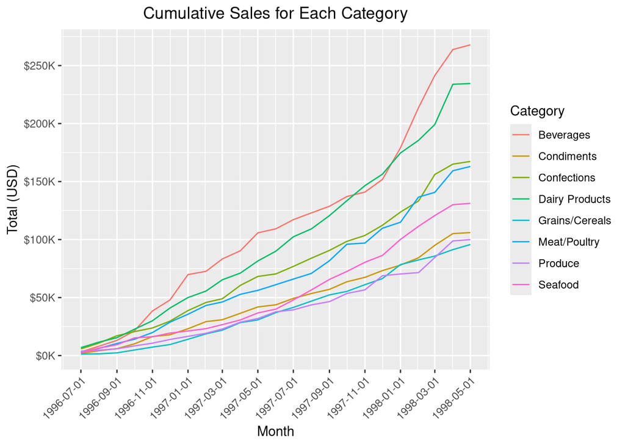

```r
fig_7 <-
  ggplot(df_7, aes(month_, total)) +
  geom_line(aes(color = category_name)) +
  scale_x_datetime(breaks = "2 months") +
  scale_y_continuous(
    breaks = seq(0, 250000, 50000),
    labels = label_dollar(scale = 0.001, suffix = "K")
  ) +
  labs(
    title = "Cumulative Sales for Each Category",
    x = "Month", y = "Total (USD)", color = "Category"
  ) +
  theme(
    plot.title = element_text(hjust = 0.5),
    axis.text.x = element_text(angle = 45, hjust = 1)
  )

fig_7
```

### 8. Top Products per Category

**With the knowledge of sales by category, the next step is to drill down further into each group. The management team wants to know the top three items sold in each product category. This will allow them to identify star performers and ensure that these products are kept in stock and marketed prominently.**

```r
df_8 <- as_tibble(dbGetQuery(conn, paste(
  "WITH product_sales AS (",
    "SELECT category_name, product_name, SUM(COALESCE(quantity, 0)) quantity",
    "FROM categories LEFT JOIN products USING (category_id)",
      "INNER JOIN order_details USING (product_id)",
    "GROUP BY 1, 2",
  "), product_ranks AS (",
    "SELECT *, ROW_NUMBER() OVER",
      "(PARTITION BY category_name ORDER BY quantity DESC) rank_",
    "FROM product_sales",
  ")",
  "SELECT category_name, product_name, quantity",
  "FROM product_ranks WHERE rank_ <= 3 ORDER BY 1, 3 DESC;"
)))

print(df_8, n = Inf)
```

```
## # A tibble: 24 × 3
##    category_name  product_name                     quantity
##    <chr>          <chr>                             <int64>
##  1 Beverages      Rhönbräu Klosterbier                 1155
##  2 Beverages      Guaraná Fantástica                   1125
##  3 Beverages      Chang                                1057
##  4 Condiments     Original Frankfurter grüne Soße       791
##  5 Condiments     Louisiana Fiery Hot Pepper Sauce      745
##  6 Condiments     Sirop d'érable                        603
##  7 Confections    Pavlova                              1158
##  8 Confections    Tarte au sucre                       1083
##  9 Confections    Sir Rodney's Scones                  1016
## 10 Dairy Products Camembert Pierrot                    1577
## 11 Dairy Products Raclette Courdavault                 1496
## 12 Dairy Products Gorgonzola Telino                    1397
## 13 Grains/Cereals Gnocchi di nonna Alice               1263
## 14 Grains/Cereals Wimmers gute Semmelknödel             740
## 15 Grains/Cereals Singaporean Hokkien Fried Mee         697
## 16 Meat/Poultry   Alice Mutton                          978
## 17 Meat/Poultry   Pâté chinois                          903
## 18 Meat/Poultry   Tourtière                             755
## 19 Produce        Manjimup Dried Apples                 886
## 20 Produce        Uncle Bob's Organic Dried Pears       763
## 21 Produce        Rössle Sauerkraut                     640
## 22 Seafood        Boston Crab Meat                     1103
## 23 Seafood        Jack's New England Clam Chowder       981
## 24 Seafood        Konbu                                 891
```

### 9. Exceptional Products

**Identify products that perform exceptionally well in terms of sales. Specifically, products whose total sales exceed the 75th percentile.**

I first created a view that stores the percentiles of each product with respect to its total number of sales.

```r
dbExecute(conn, paste(
  "CREATE VIEW product_percentiles AS",
  "WITH product_sales AS (",
    "SELECT product_name, SUM(quantity)::int quantity",
    "FROM products INNER JOIN order_details USING (product_id)",
    "GROUP BY 1",
  ")",
  "SELECT *, CUME_DIST() OVER (ORDER BY quantity) perc",
  "FROM product_sales;"
))
```

I then created a function that generalizes the solution to an arbitrary percentile *p*, returning all products whose total sales exceed the *p-th* percentile.

```r
dbExecute(conn, paste(
  "CREATE FUNCTION products_over_percentile(percentile_ real)",
  "RETURNS TABLE (product varchar, num_sold int, percentile double precision)",
  "LANGUAGE plpgsql AS $$ BEGIN RETURN QUERY",
  "SELECT * FROM product_percentiles",
  "WHERE perc > percentile_ / 100",
  "ORDER BY 3 DESC, 1; END $$;"
))
```

```r
df_9 <- as_tibble(dbGetQuery(conn, (
  "SELECT * FROM products_over_percentile(75);"
)))

df_9
```

```
## # A tibble: 20 × 3
##    product                         num_sold percentile
##    <chr>                              <int>      <dbl>
##  1 Camembert Pierrot                   1577      1
##  2 Raclette Courdavault                1496      0.987
##  3 Gorgonzola Telino                   1397      0.974
##  4 Gnocchi di nonna Alice              1263      0.961
##  5 Pavlova                             1158      0.948
##  6 Rhönbräu Klosterbier                1155      0.935
##  7 Guaraná Fantástica                  1125      0.922
##  8 Boston Crab Meat                    1103      0.909
##  9 Tarte au sucre                      1083      0.896
## 10 Chang                               1057      0.883
## 11 Flotemysost                         1057      0.883
## 12 Sir Rodney's Scones                 1016      0.857
## 13 Jack's New England Clam Chowder      981      0.844
## 14 Lakkalikööri                         981      0.844
## 15 Alice Mutton                         978      0.818
## 16 Pâté chinois                         903      0.805
## 17 Konbu                                891      0.792
## 18 Manjimup Dried Apples                886      0.779
## 19 Steeleye Stout                       883      0.766
## 20 Chai                                 828      0.753
```

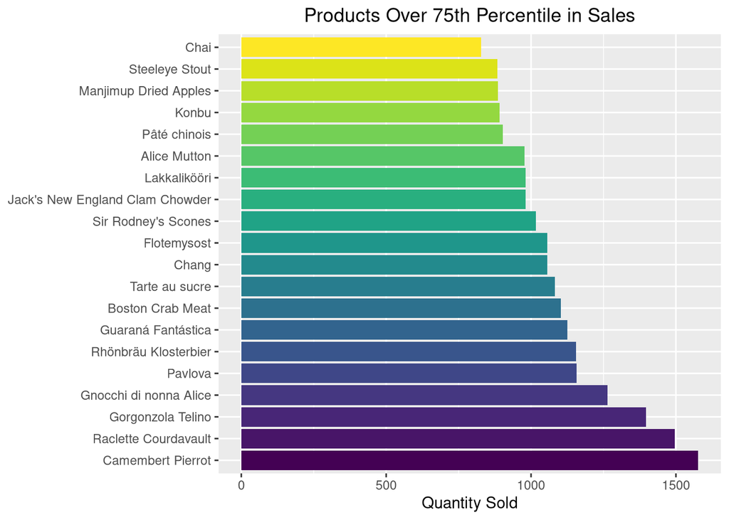

```r
df_9$product <- factor(df_9$product, levels = df_9$product)

fig_9 <-
  ggplot(df_9, aes(num_sold, product)) +
  geom_col(aes(fill = product)) +
  scale_fill_viridis_d(guide = "none") +
  labs(title = "Products Over 75th Percentile in Sales", x = "Quantity Sold", y = NULL) +
  theme(plot.title = element_text(hjust = 0.5))

fig_9
```